# Lecture_4_assignment

Chen, Yen-Ting

2021/10/19

# Assignment 4

```r
pacman::p_load(dyplr, tidyr, ggplot2)
```

Premise

One unrealistic feature of the discrete logistic growth equation is that $N_{t+1}$ will become negative when $N_t >> K$ (you’ve probably saw this when playing with the shiny app). An alternative approach is to follow the Ricker logistic equation (Ricker, 1952), a well-known model in fisheries:

$$N_{t+1} = N_te^{r(1-\frac{N_t}{K})}$$

## Q1

Show analytically the equilibrium points and determine their stability criteria. Compare the stability criteria of this model to those of the standard discrete logistic model.

### Solution

#### Part 1

Equilibrium can be sought by acknowledging that $N_{t+1} = N_t = N^*$, where $N^*$ is the population size at equilibrium. Thereby, we can rewrite the Ricker logistic equation by substituting all $N$s into $N^*$, giving $N^*= N^*e^{r(1-\frac{N^*}{K})}$. At this step, we can pause right here and look at the equation. The first solution that comes to us immediately is the trivial solution $N^* = 0$, which can be sought by plug in zeros to all $N^*$ into the equation (I mean, you cannot grow your population from nothing). The other solution $N^* = K$ is equally easy to seek since the $e^{r(1-\frac{N^*}{K})}$ part must equal to 1, $N^*$ must be $K$ for fulfulling $e^0 = 1$.

#### Part 2:

Now, to determine the stability at $N^* = 0,~K$, we could evaluate the rate of change of some amount of individuals $\epsilon$ after its introduction to the population at equilibrium. If the introduction of $\epsilon$ drives the population size away from an $N^*$ overtime, the population size $N^*$ is unstable.

Following this idea, we can first define $\epsilon_t = N_t- N^*$, which describes the new population size at time t $N_t$ is away from the current population size reference point $N^*$ by an amount of $\epsilon$. After the next time interval, $\epsilon_{t+1} = N_{t+1}- N^*$.

Now I rewrite the Ricker logistic equation as $Ne^{r(1-\frac{N}{K})}=F(N)$ and substitute $N_{t+1}$ with $F(N_t)$, I can get a new equation:

$\epsilon_{t+1} = F(N_t)- N^*$

Further substituting $N_t$ as the reference point plus the newly introduced individuals $N^* + \epsilon$, I can get the following:

$\epsilon_{t+1} = F(N^* + \epsilon)- N^*$

With $F(N^* + \epsilon)$, I can estimate the term via Talyor expansion and get the below equation:

$\epsilon_{t+1} = F(N^*) + \epsilon F'(N^*) + \theta(\epsilon^2) - N^*$

After cancelling $F(N^*)$ with $N^*$ and omit the higher order terms $\theta(\epsilon^2)$, I can finally derive $\epsilon_{t+1} = \epsilon F'(N^*)$ where you can translate this equation as the change of $\epsilon$ after one time interval is $\epsilon$ times the rate of change at equilibrium population size. If $|F'(N^*)|~>~1$, $N^*$ is unstable; if $|F'(N^*)|~<~1$, the population would be stable.

Now the work is to evaluate $\frac{dF}{dN}$ at $N^*$ where $F(N)= Ne^{r(1-\frac{N}{K})}$. Using the product rule and the chain rule, we can eventually get the following:

$$\frac{dF}{dN} = e^{r{(1-\frac{N}{K})}}+N(-\frac{r}{K})e^{r{(1-\frac{N}{K})}}\\
= e^{r{(1-\frac{N}{K})}}(1-\frac{rN}{K})$$

When $N^* = 0$, $F'(0) = e^r$; when $N^* = K$, $F'(K) = 1-r$.

#### Part 3:

Comparing the stability of the Ricker logistic model (RLM) and the standard discrete logistic models (DLM) we have discussed in class, it is obvious that the DLM does not exactly behave like an biological system.

Since the behavior around $N^* = 0$ is different between the Ricker logistic model and the discrete logistic model, naturally I would like to investigate the behaviors at $N^* = 0$.

For comparing the two models at $N = 0$, I choose to use numerical methods by constructing models with different different sets of growth rates above/below $-2$. In figure 1, we can see that the all negative growth rates in DLM except -0.5 surpasses the supposed lower bound (i.e., 0). The smooth approaching behavior of $r = -0.5$ matches the prediction in Dr. Ko’s class. On the other hand, the result of all the Ricker logistic models did not go below zero. This generally suggests that the Ricker logistic model is a better template for modelling biological systems than the discrete logistic model since no biological system can have negative individuals/biomass/etc.

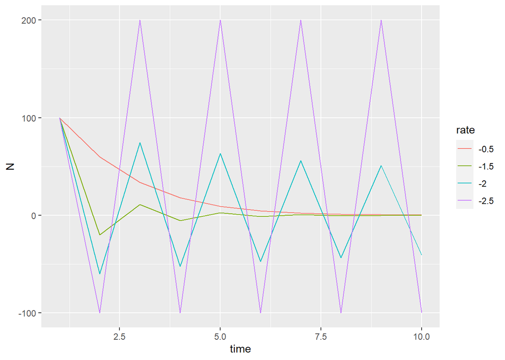

```r
k = 500
time = 10 # end time
N <- 100 # setting initial population

# set up data frame
pop_data <- data.frame(time = 1:time, # set up a data frame with time from 1 to 100
                       r_2.5 = N,
                       r_2 = N,
                       r_1.5 = N, # with epsilon
                       r_0.5 = N)

discrete_log <- function(N, r) N * (1 + r * (1 - (N / k))) # eq

for(i in 2:time) { # the change in "i"th row is dependent from the "i-1"th row
  pop_data[i, 2] <-  discrete_log(pop_data[i-1, 2], r = -2.5)
  pop_data[i, 3] <-  discrete_log(pop_data[i-1, 3], r = -2)
  pop_data[i, 4] <-  discrete_log(pop_data[i-1, 4], r = -1.5)
  pop_data[i, 5] <-  discrete_log(pop_data[i-1, 5], r = -0.5)
}

colnames(pop_data)[2:5] <- c("-2.5", "-2", "-1.5", "-0.5")

pop_data %>%
  pivot_longer(cols = c("-2.5", "-2", "-1.5", "-0.5"), names_to = "rate", values_to = "N") %>%
  #filter(rate != "-4") %>%
  ggplot(aes(x = time, y = N, color = rate)) +
  geom_line(size = 0.5)
```

Figure 1. The model result of the discrete logistic model with an initial population of 100, carry capacity of 500, and a series of growth rates ranging from -0.5 to -2.5.

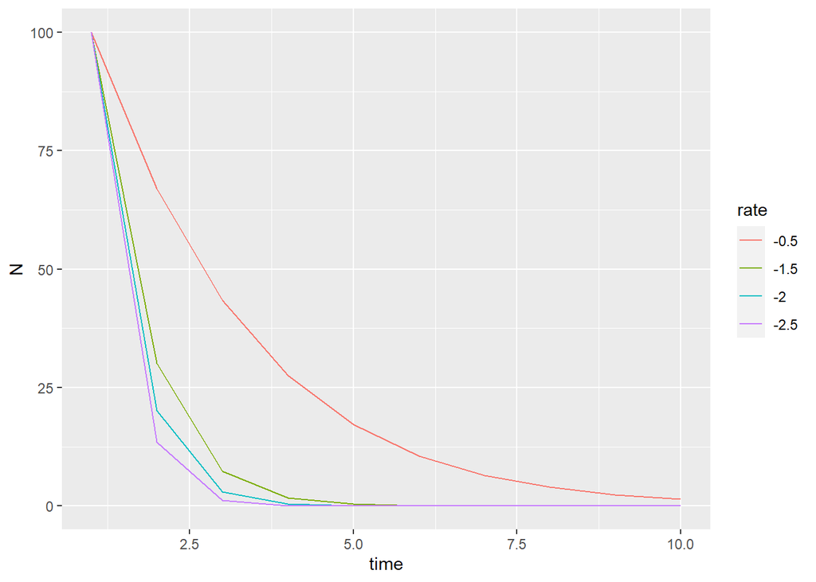

```r
k = 500
time = 10 # end time
N <- 100 # setting initial population

# set up data frame
pop_data <- data.frame(time = 1:time, # set up a data frame with time from 1 to 100
                       r_4 = N,
                       r_2 = N,
                       r_1.5 = N, # with epsilon
                       r_0.5 = N)

ricker_log <- function(N, r) N * exp(r * (1 - (N / k))) # eq

for(i in 2:time) { # the change in "i"th row is dependent from the "i-1"th row
  pop_data[i, 2] <-  ricker_log(pop_data[i-1, 2], r = -2.5)
  pop_data[i, 3] <-  ricker_log(pop_data[i-1, 3], r = -2)
  pop_data[i, 4] <-  ricker_log(pop_data[i-1, 4], r = -1.5)
  pop_data[i, 5] <-  ricker_log(pop_data[i-1, 5], r = -0.5)
}

colnames(pop_data)[2:5] <- c("-2.5", "-2", "-1.5", "-0.5")

pop_data %>%
  pivot_longer(cols = c("-2.5", "-2", "-1.5", "-0.5"), names_to = "rate", values_to = "N") %>%
  ggplot(aes(x = time, y = N, color = rate)) +
  geom_line(size = 0.5)
```

## Q2

Plot the population trajectories under three growth scenarios $r = 0.5$, $r= 1.5$, and $r = 2.7$ ($N_0 = 10, K = 500$, 100 time steps for each simulation). Please include the R code you used to generate the results.

### Solution

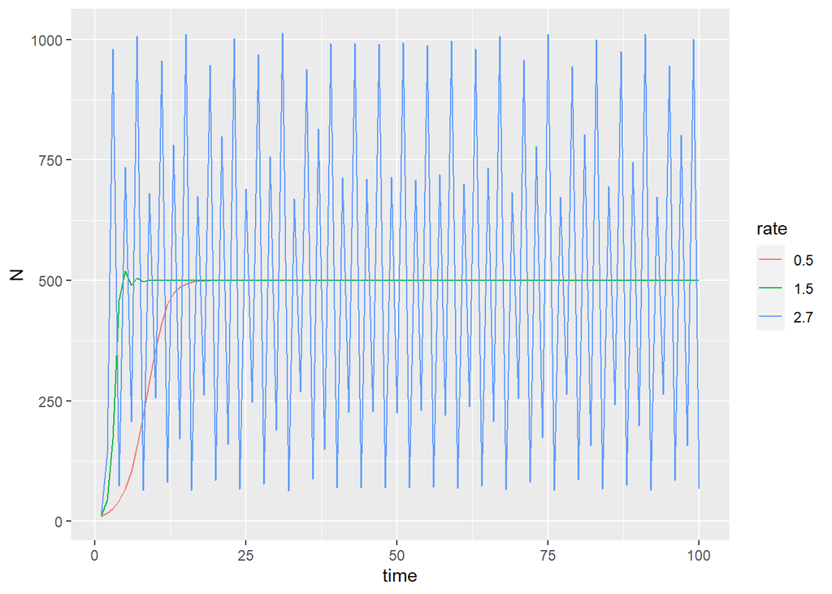

```r
k = 500
time = 100 # end time
N <- 10 # setting initial population

# set up data frame
pop_data <- data.frame(time = 1:time, # set up a data frame with time from 1 to 100
                       r_0.5 = N,
                       r_1.5 = N,
                       r_2.7 = N)

ricker <- function(N, r) N * exp(r * (1 - (N / k))) # eq

for(i in 2:time) { # the change in "i"th row is dependent from the "i-1"th row
  pop_data[i, 2] <-  ricker(pop_data[i-1, 2], r = 0.5)
  pop_data[i, 3] <-  ricker(pop_data[i-1, 3], r = 1.5)
  pop_data[i, 4] <-  ricker(pop_data[i-1, 4], r = 2.7)
}

colnames(pop_data)[2:4] <- c("0.5", "1.5", "2.7")

pop_data %>%
  pivot_longer(cols = c("0.5", "1.5", "2.7"), names_to = "rate", values_to = "N") %>%
  ggplot(aes(x = time, y = N, color = rate)) +
  geom_line(size = 0.5)
```

```r
  #geom_point(size =3)
```